# ISLR - Chap3

GT

October 6, 2016

## Chapter 3 - Linear Regression

Linear regression is a useful tool for predicting a quantitative response. Recall the *`Advertising`* data that contains *`sales`*. for a particular product as a function of advertising budget for *`TV`*, *`radio`*, *`newspaper`* media. Suppose that as statistical consultant we are asked to suggest, on the basis of this data, a marketing plan for next year that will result in high product sales. What information would be useful in order to provide such a reccomendation? Here are a few important questions that we might seek to address:

1. Is there a relationship between advertising budget and sales ?
2. How strong is the relationship between advertising budget and sales ?
3. Which media contribute to sales?
4. How accurately can we estimate the effect of each medium on sales ?
5. How accurately can we predict future sales ?
6. Is the relationship linear ?
7. Is there synergy among the advertising media?

### Simple Linear Regression

*Simple linear regression* lives up to its name it is a very straightforward approach for predicting a quantitative response $Y$ on the basis of a single predictor variable $X$. It assumes that there is approximately a linear relationship between $X$ and $Y$.

$$Y\approx\beta_0+\beta_1X$$

You might read “$\approx$” as “*is approximately modeled as*”. We will sometimes describe the equation by saying that we are *regressing Y on X*. For example, $X$ may represent *`TV`* advertising and $Y$ may represent *`sales`*. Then we can regress *`sales`* onto *`TV`* by fitting the model.

$$\textbf{sales}\approx\beta_0+\beta_1\times\textbf{TV}$$

$\beta_0$ and $\beta_1$ are two unknown constants that represent the *intercept* and *slope* terms in the linear model. Together, they are known as the model *coefficients* or *parameters*. Once we have used our training data to produce estimates $\hat{\beta}_0$ and $\hat{\beta}_1$ for the model coefficients, we can predict future sales on the basis of a particular value of TV advertising by computing

$$\hat{y}=\hat{\beta}_0+\hat{\beta}_1x$$

where $\hat{y}$ indicates a prediction of $Y$ of the basis of $X=x$. Here we use a *hat* symbol, ^, to denote the estimated value for un unknown parameter or coefficient, or to denote the predicted value of the response.

#### Estimating the Coefficients

In practice, $\beta_0$ and $\beta_1$ are unknown. So before we can make predictions, we must use data to estimate the coefficients. Let

$$(x_1,y_1),(x_2,y_2),…,(x_n,y_n)$$

represent $n$ observation pairs, each of which consists of a measurement of $X$ and a measurement of $Y$. In the *`Advertising`* example, this data set consist of the TV advertising budget and product sales in $n=200$ different markets. Our goal is to obtain coefficient estimates $\hat{\beta}_0$ and $\hat{\beta}_1$ such that the linear model fits the available data well so that $y_i\approx\hat{\beta}_0+\hat{\beta}_1x_i$ for $i=1,…,n$. In other words, we want to find a intercept $\hat{\beta}_0$ and a slope $\hat{\beta}_1$ such that the resulting line is as close as possible to the $n=200$ data points.

There are a number of ways of measuring *closeness*. However, by far the most common approach involves minimizing the *last squares* criterion.

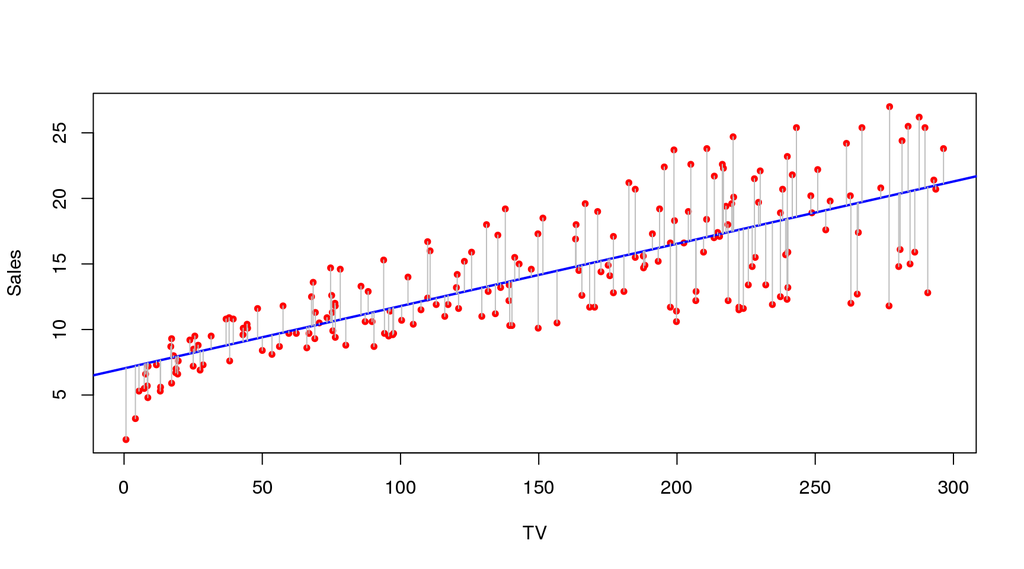

Let $\hat{y}_i=\hat{\beta}_0+\hat{\beta}_1x_1$ be the prediction for $Y$ based on the $i$ th value of $X$. Then $e_i=y_i-\hat{y}_i$ represent the $i$ th *residual*, this is the difference between the $i$ th observed response value and the $i$ th response value that is predicted by our linear model. We define the *residual sum of squares* (RSS) as

$$RSS=e_1^2+e_2^2+…+e_n^2$$

or equivalently as

$$RSS = (y_1-\hat{\beta}_0-\hat{\beta}_1x_1)^2+(y_2-\hat{\beta}_0-\hat{\beta}_1x_2)^2+…+(y_n-\hat{\beta}_0-\hat{\beta}_1x_n)^2$$

The least squares approach chooses $\hat{\beta}_0$ and $\hat{\beta}_1$ to minimize the RSS. Using some calculus, one can show that minimizers are

$$\hat{\beta}_1=\frac{\sum_{i=1}^{n}(x_i-\bar{x})(y_i-\bar{y})}{\sum_{i=1}^{n}(x_i-\bar{x})^2}$$

$$\hat{\beta}_0=\bar{y}-\hat{\beta}_1\bar{x}$$

where $\bar{y}\equiv\frac{1}{n}\sum_{i=1}^{n}y_i$ and $\bar{x}\equiv\frac{1}{n}\sum_{i=1}^{n}x_i$ are the sample maeans. In other words the equation defines the *least squares coefficient* *estimates* for simple linear regression.

In the previously figure, the simple linear regression fit for the *`Advertising`* data, where $\hat{\beta}_0$=7.03 and $\hat{\beta}_1$=0.0475. In other words, according to this approximation, an additional $1000 spent on TV advertising is associated with selling approximately 47.5 additional units of product.

#### Assessing the Accuracy of thfe Coefficient Estimates

We assume that the *true* relationship between $X$ and $Y$ takes the form $Y=f(X)+\epsilon$ for some unknown function $f$, where $\epsilon$ is a mean-zero random error term. If $f$ is to be apporximated by a linear function, then we can write this relationship as

$$Y=\beta_0+\beta_1X+\epsilon$$

Here $\beta_0$ is the intercept term (the value of $Y$ when $X=0$) and $\beta_1$ is the slope (average increase if $Y$ when $X$ increases by one-unit). The error term is a catch-all for what we miss with this simple model: the true relationship is probably not linear, there may be other variables that cause variation in $Y$, and there may be measurement error. We typically assume that the error term is independent of $X$.

This model defines the *population regression line*, which is the best linear approximation to the true relationship between $X$ and $Y$. The least squares regression coefficient estimates the *least squares* *line*. The true relationship is generally not known for real data, but the least squares line can always be comptuted using the coefficient estimates. In real applications, we have access to a set of observations from which we can compute the least squares line, however the population regression line is unobserved.

At first glance, the difference between the population regression line and the least squares line may seem subtle and confusing. We only have one data set, and so what does it mean that two different lines describe the relationship between the predictor and the response ?

Fundamentally, the concept of these two lines is a natural extension of the standard statistical approach using information from a sample to estimate characteristics of a large population. For example, suppose that we are interested in knowing the population mean $\mu$ of some random variable $Y$. Unfortunately, $\mu$ is unknown, but we do have access to $n$ observations from $Y$, which we can write as $y_1,\ldots,y_n$, and which we can use to estimate $\mu$. A reasonable estimate is $\hat{\mu}=\bar{y}$, where $\bar{y}=\frac{1}{n}\sum_{i=1}^{n}y_i$ is the sample mean. The sample mean and the population mean are different, but in general the sample mean will provide a good estimate of the population mean. In the same way, the unknown coefficients $\beta_0$ and $\beta_1$ in linear regression define the population regression line. We seek to estimate these unknown coefficients using $\hat{\beta}_0$ and $\hat{\beta}_1$. These coefficient estimates define the least squares line.

The analogy between linear regression and estimation of the mean of a random variable is an apt one based on the concept of *bias*. If we use the sample mean $\hat{\mu}$ to estimate $\mu$, this estimate is *unbiased*, in the sense that on average, we expect $\hat{\mu}$ to equal $\mu$. What exactly does this mean ? It means that on the basis of one particular set of observations $y_1,\ldots,y_n$, $\hat{\mu}$ might overestimate $\mu$, and on the basis of another set of observations, $\hat{\mu}$ might underestimate $\mu$. But if we could average a huge number of estimates of $\mu$ obtained from a huge number of sets of observations, then this average would *exactly* equal $\mu$. Hence, an unbiased estimator does not *systematically* over- or under- estimate the true parameter. The property of unbiasedness holds for the least squares coefficient estimates as well: if we estimate $\beta_0$ and $\beta_1$ on the basis of a particular data set, then our estimates won’t be exactly equal to $\beta_0$ and $\beta_1$. But if we could average the estimates obtained over a huge number of data sets, then the average of these estimates would be spot on!

We continue the analogy with the estimation of the population mean $\mu$ of a random variable $Y$. A natural question is as follows: how accurate is the sample mean $\hat{\mu}$ as an estimate of $\mu$? We have established that the average of $\hat{\mu}$’s over many data sets will be very close to $\mu$ but that a single estimate $\hat{\mu}$ may be a substantial understimate or overestimate of $\mu$. How har off will that sigle estimate of $\hat{\mu}$ be ? In general, we answer this question by computing the *standard error* of $\hat{\mu}$, written as SE($\hat{\mu}$).

$$Var(\hat{\mu})=SE(\hat{\mu})^2=\frac{\sigma^2}{n}$$

where $\sigma$ is the standard deviation of each of the realization $y_i$ of $Y$. Roughly speaking, the standard error tells us the average amount that this estimate $\hat{\mu}$ differs from the actual value of $\mu$. The equation also tells us how this deviation shrinks with $n$, the more observations we have, the smalle the standard error of $\hat{\mu}$. In a similar vein, we can wonder how close $\hat{\beta}_0$ and $\hat{\beta}_1$ are to the true values $\beta_0$ and $\beta_1$. To compute the standard errors associated with $\hat{\beta}_0$ and $\hat{\beta}_1$, we use the following formulas:

$$SE(\hat{\beta}_0)^2=\sigma^2[\frac{1}{n}+\frac{\bar{x}^2}{\sum_{i=1}^{n}(x_i-\bar{x})^2}]$$
,
$$SE(\hat{\beta}_1)^2=\frac{\sigma^2}{\sum_{i=1}^{n}(x_i-\bar{x})^2}$$

where $\sigma^2=Var(\epsilon)$. For these formulas to be strictly valid, we need to assume that the errors $\epsilon_i$ for each observation are uncorrelated with commom variance $\sigma^2$. This turns out to be a good approximation. Notice in the formula that $SE(\hat{\beta}_1)$ is smaller when the $x_i$ are more spread out; intuitively we have more *levarage* to estimate a slope when this is the case. We also see that $SE(\hat{\beta}_0)$ would be the same as $SE(\hat{\mu})$ if $\bar{x}$ were zero.

In general, $\sigma^2$ is not known, but can be estimated from the data. The estimate of $\sigma$ is known as the *residual standard error*, and is given by the formula

$$RSE=\sqrt{\frac{RSS}{n-2}}$$

Strictly speaking, when $\sigma^2$ is estimated from the data we should write $\hat{SE}(\hat{\beta}_1)$ to indicate that an estimate has been made, but for simplicity of notation we will drop this extra “hat”.

Standard erros can be used to compute *confidence intervals*. A 95% confidence interval is defined as a range of values such that with 95% probability, the range will contain the true unknown value of the parameter. The range is defined in terms of lower and upper limits computed from the sample of data. For linear regression, the 95% confidence interval for $\beta_1$ approximately takes the form

$$\hat{\beta}_1\pm 2\cdot SE (\hat{\beta}_1)$$

That is, there is approximately a 95% chance that the interval

$$[\hat{\beta}_1-2\cdot SE (\hat{\beta}_1),\hat{\beta}_1+2\cdot SE (\hat{\beta}_1)]$$

will contain the true value of $\beta_1$. Similarly, a confidence interval for $\beta_0$ approximately takes the form

$$\hat{\beta}_0\pm 2\cdot SE (\hat{\beta}_0)$$

In the case of the advertising data, the 95% confidence interval for $\beta_0$ is [6.130,7.935] and the 95% confidence interval for $\beta_1$ is [0.042,0.053]. Therefore, we can conclude that in the absence of any advertising, sales will, on average, fall somewhere between 6130 and 7940 units. Furthermore, for each $1000 increase in television and advertising, there will be an average increase in sales of between 42 and 53 units.

Standard errors can also be used to perform *hypothesis tests* on the coefficients. The most common hypothesis test involves testing the *null hypothesis* of

> $H_0$: There is no relationship between $X$ and $Y$

versus the *alternative hypothesis*

> $H_a$: There is some relationship between $X$ and $Y$

Mathematically, this corresponds to testing

$$H_0:\beta_1=0$$

versus

$$H_a:\beta_1\neq0$$

$$t=\frac{\hat{\beta}_1-0}{SE(\hat{\beta}_1)}$$

which measures the number of standard deviations the number of standard deviations that $\hat{\beta}_1$ is away from 0. If there really is no relationship between $X$ and $Y$, then we expect that we’ll have a *t*-distribution with $n-2$ degrees of freedom. The t-distribution has a bell shape and for values of $n$ greater than approximately 30 it is quite similar to the normal distribution. Consequently, it is a simple matter to compute the probability of observing any value equal to $|t|$ or larger, assuming $\beta_1=0$. We call this probability the *p-value*. Roughly speaking, we interpret the p-value as follows: a small p-value indicates that it is unlikely to observe such a substantial association between the predictor and the response due to chance, in the absence of any real association between the predictor and the response. Hence if we see a small p-value, then we can infer that there is an association between the predictor and the response. We *reject the null hypothesis*, that is, we declare a relationship to exist between $X$ and $Y$, if the p-value is small enough. Typical p-value cutoffs for rejecting the null hypothesis are 5 or 1%. When $n=30$, these correspond to t-statistics of around 2 and 2.75, respectively.

```
## Coefficients:
##             Estimate Std. Error t value Pr(>|t|)
## (Intercept) 7.032594   0.457843   15.36   <2e-16 ***
## TV          0.047537   0.002691   17.67   <2e-16 ***
```

The table provides details of the least squares model for the regression of number of units sold on TV advertising budget for the *`Advertising`* data. Notice that the coefficients for $\hat{\beta}_0$ and $\hat{\beta}_1$ are very large relative to their standard errors, so the t-statistics are also large; the probabilities of seeing such values if $H_0$ is true are virtually zero. Hence we can conclude that $\beta_0\neq0$ and $\beta_1\neq0$.

#### Assessing the Accuracy of the Model

Once we have rejected the null hypothesis in favor of the alternative hypothesis, it is natural to want to quantify *the extent to which the model fits the data*. The quality of a linear regression fit is typically assessed using two related quantities: the *residual standard error* (RSE) and the $R^2$ statistic.

```
## Residual standard error: 3.259 on 198 degrees of freedom
## Multiple R-squared:  0.6119, Adjusted R-squared:  0.6099
## F-statistic: 312.1 on 1 and 198 DF,  p-value: < 2.2e-16
```

The table displays the RSE, the $R^2$ statistic and the F-statistic for the linear regression of number of units sold on TV advertisign budget.

**Residual Standard Error**

Recall that associated with each observation is an error term $\epsilon$. Due to the presence of these error terms, even if we knew the true regression line, we would not be able to perfectly predict $Y$ from $X$. The RSE is an estimate of the standard deviation of $\epsilon$. Roughly speaking, it is the average amount that the response will deviate from the true regression line. It is computed using the formula

$$RSE=\sqrt{\frac{1}{n-2}RSS}=\sqrt{\frac{1}{n-2}\sum_{i=1}^{n}(y_i-\hat{y}_i)^2}$$

Note that the RSS is given by the formula:

$$RSS=\sum_{i=1}^{n}(y_i-\hat{y}_i)^2$$

In the case of the advertisig data, we see from the linear regression output that the RSE is 3.26. In other words, actual sales in each market deviate from the true regression by approximately 3260 units, on average. Another way to think about this is that even if the model were correct and the true values of the unknown coefficients $\beta_0$ and $\beta_1$ were known exactly, any prediction of sales on the basis of TV advertising would still be off by about 3260 units on average. Of course, wheter or not 3260 units is an acceptable prediction error depends on the problem context. In the advertising data set, the mean volume of *`sales`* over all markets is approximately 14000 units, and so the percentage error is 3260/14000=23%.

The RSE is considered a measure of the *lack of fit* of the model to the data. If the predictions obtained using the model are very close to the true outcome values, $\hat{y}_i\approx y_i$ for $i=1,\ldots,n$, then RSE will be small and we can conclude that the model fits the data very well. On the other hand, if $\hat{y}_i$, is very far from $y_i$, for one or more observations, then the RSE may be quite large, indicating that the model doesn’t fit the data well.

**$R^2$ Statistic**

The RSE provides an absolute measure of lack of fit of the model to the data. But since it is measured in the units of $Y$, it is not always clear what constitutes a good RSE. The $R^2$ statistic provides an alternative measure of fit. It takes the form of a *proportion*, the proportion of variance explained, and so it always takes on a value between 0 and 1, and is independent of the scale of Y.

To calculate $R^2$, we use the formula

$$R^2=\frac{TSS-RSS}{TSS}=1-\frac{RSS}{TSS}$$

where $TSS=\sum(y_i-\bar{y})^2$ is the *total sum of squares*, and $RSS=\sum_{i=1}^{n}(y_i-\hat{y}_i)^2$. TSS measures the total variance in the response $Y$, and can be thought of as the amount of variability inherent in the response before the regressino is performed. In contrast, RSS measures the amount of variability that is left unexplained after performing the regression. Hence, $TSS-RSS$ measures the amount of variability in the response that is explained by performing the regression, and $R^2$ measures the *proportion of variability in Y that can be explained using X*. An $R^2$ statistic that is close to 1 indicates that a large proportion of the variability in the response has been explained by the regression. A number near 0 indicates that the regression did not explain much of the variability in the response; this might occur because the linear model is wrong, or the inherent error $\sigma^2$ is high, or both. In the previous table, the $R^2$ was 0.61, and so just under two-thirds of the variability in *`sales`* is explained by a linear regression on *`TV`*.

The $R^2$ statistic has an interpretational advantage over the RSE, since unlike the RSE, it always lies between 0 and 1. However, it can still be challenging to determine what is *good $R^2$* value, and in general, this will depend on the application. For instance, in certain problems in physics, we may know that the data truly comes from a linear model with a small residual error. In this case, we would expect to see an $R^2$ value that is extremely close to 1, and a substantially smaller $R^2$ value might indicate a serious problem with the experiment in which the data were generated. On the other hand, in typical applications in biology, psychology, marketing, and other domains, the linear model is at best an extremely rough approximation to the data and residual errors due to other unmeasured factors are often very large. In this setting, we would expect only a very small proportion of the variance in the response to be explained by the predictor, and an $R^2$ value well below 0.1 might be more realistic!

The $R^2$ statistic is a measure of the linear relationship between $X$ and $Y$. Recall that *correlation*, defined as

$$Cor(X,Y)=\frac{\sum_{i=1}^{n}(x_i-\bar{x})(y_i-\bar{y})}{\sqrt{\sum_{i=1}^{n}(x_i-\bar{x})^2}\sqrt{\sum_{i=1}^{n}(y_i-\bar{y})^2}}$$

is also a measure of the linear relationship between $X$ and $Y$. This suggests that we might be able to use $r=Cor(X,Y)$ instead of $R^2$ in order to asses the fit of the linear model. In fact, it can be shown that in the simple linear regression setting, $R^2=r^2$. In other words, the squared correlation and the $R^2$ statistic are identical.

### Multiple Linear Regression

Simple linear regression is a useful approach for predicting a response on the basis of a sigle predictor variable. However, in practice we often have more than one predictor. For example, in the *`Advertising`* data, we have examined the relationship between sales and TV advertising. We also have data for the amount of money spent advertising on the radio and in newspapers, and we may want to know whether either of these two media is associated with sales. How can we extend our analysis of the advertising data in order to accomodate these two additional predictors?

One option is to run three separate simple linear regressions, each of which uses a different advertising medium as a predictor. For instance, we can fit a simple linear regression to predict sales on the basis of the amount spent on radio advertisements.

```
## Coefficients:
##             Estimate Std. Error t value Pr(>|t|)
## (Intercept)  9.31164    0.56290  16.542   <2e-16 ***
## Radio        0.20250    0.02041   9.921   <2e-16 ***
##
##
## Coefficients:
##             Estimate Std. Error t value Pr(>|t|)
## (Intercept) 12.35141    0.62142   19.88  < 2e-16 ***
## Newspaper    0.05469    0.01658    3.30  0.00115 **
```

We find that a $1000 increase in spending on radio advertising is associated with an increase in sales by around 203 units. A $1000 increase in newspaper advertising budget is associated with an increase in sales by approximately 55 units.

However, the approach of fitting a separate simple linear regression model for each predictor is not entirely satisfactory. First of all, it is unclear how to make a single prediction of sales given levels of the three advertising media budgets, since each of the budgets is associated with a separate regression equation. Second, each of the three regression equations ignores the other two media in forming estimates for the regression coefficients. We will see that if the media budgets are correlated with each other in the 200 markets that constitute our data set, then this can lead to very misleading estimates of the individual media effects on sales.

Instead of fitting a separate simple linear regression model for each predictor, a better approach is to extend the simple linear regression model so that it can directly accomodate multiple predictors. We can do this by giving each predictors a separate slope coefficient in a single model. In geeneral, suppose that we have $p$ distinct predictors. Then the multiple linear regression model thakes the form

$$Y=\beta_0+\beta_1 X_1+\beta_2 X_2+\cdots+\beta_p X_p+\epsilon$$

where $X_j$ represent the $j$ th predictor and $\beta_j$ quantifies the association between that variable and the response. We interpret $\beta_j$ as the *average* effect on $Y$ of a one unit increase in $X_j$, *holding all other predictors fixed*. In the advertising example, becames

$$sales=\beta_0+\beta_1\times TV+\beta_2\times radio+\beta_3\times newspaper + \epsilon$$

#### Estimating the Regression Coefficients

As was the case in the simple linear regression setting, the regression coefficients $\beta_0,\beta_1,\ldots,\beta_p$ are unknown, and must be estimated. Given estimates $\hat{\beta_0},\hat{\beta_1},\ldots,\hat{\beta_p}$, we can make predictions using the formula

$$\hat{y}=\hat{\beta_0}+\hat{\beta_1}x_1+\hat{\beta}_2x_2+\cdots+\hat{\beta_p}x_p$$

The parameters are estimated using the same least squares approach that we saw in the context of simple linear regression. We choose $\hat{\beta_0},\hat{\beta_1},\ldots,\hat{\beta_p}$ to minimize the sum of squared residuals

$$RSS=\sum_{i=1}^{n}(y_i-\hat{y}_i)^2=\sum_{i=1}^{n}(y_i-\hat{\beta_0}-\hat{\beta_1}x_{i1}-\hat{\beta}_2x_{i2}-\cdots-\hat{\beta_p}x_{ip})^2$$

Any statistical software package can be used to compute the the multiple least squares regression estimates, $\hat{\beta_0},\hat{\beta_1},\ldots,\hat{\beta_p}$ that minimize the equation.

```
## Coefficients:
##              Estimate Std. Error t value Pr(>|t|)
## (Intercept)  2.938889   0.311908   9.422   <2e-16 ***
## TV           0.045765   0.001395  32.809   <2e-16 ***
## Radio        0.188530   0.008611  21.893   <2e-16 ***
## Newspaper   -0.001037   0.005871  -0.177     0.86
```

The table displays the multiple regression coefficient estimates when TV, radio and newspaper advertising budgets are used to predict product sales using the *`Advertising`* data. We interpret these results as follows: for a given amount of TV and newspaper advertising, spending an additional $1000 on radio advertising leads to an increase in sales by approximately 189 units. Comparing these coefficient estimates to those displayed previously, we notice that the multiple regression coefficient estimates for *`TV`* and *`radio`* are pretty similar to the simple linear regression coefficient estimates. However, while the *`newspaper`* regression coefficient estimate for *`newspaper`* in the multiple regression model is close to zero, and the corresponding p-value is no longer significant, with a value around 0.86. This illustrates that the simple and multiple regression coefficients can be quite different. This difference stems from the fact that in the simple regression case, the slope term represents the average effect of a $1000 increase in newspaper advertising, ignoring other predictors such as *`TV`* and *`radio`*. In contrast, in the multiple regression setting, the coefficient for *`newspaper`* represents the average effect of increasing newspaper spending by $1000 while holding *`TV`* nad *`radio`* fixed.

Does it make sense for the multiple regression to suggest no relationship between *`sales`* and *`newspaper`* while the simple linear regression implies the opposite ? In fact it does.

Consider the correlation matrix for the three predictor variables and response variable.

```
##                   TV      Radio  Newspaper     Sales
## TV        1.00000000 0.05480866 0.05664787 0.7822244
## Radio     0.05480866 1.00000000 0.35410375 0.5762226
## Newspaper 0.05664787 0.35410375 1.00000000 0.2282990
## Sales     0.78222442 0.57622257 0.22829903 1.0000000
```

Notice that the correlation between *`radio`* and *`newspaper`* is 0.35. This reveals a tendency to spend more on newspaper advertising in markets where more is spent on radio advertising. Now suppose that the multiple regression is correct and newspaper advertising has no direct impact on sales, but radio advertising does increase sales. Then in markets where we spend more on radio our sales will tend to be higher, and as our correlation matrix shows, we also tend to spend more on newspaper advertising in those same markets. Hence, in a simple linear regression which only examines *`sales`* versus *`newspaper`*, we will observe that higher values of *`newspaper`* tend to be associated with higher values of *`sales`*, even though newspaper advertising does not actually affect sales. So *`newspaper`* sales are a surrogate for *`radio`* advertising; *`newspaper`* gets “credit” for the effect of *`radio`* on *`sales`*.

The slightly countreintuitive result is very common in many real life situations. Consider an absurd example to illustrate the point. Running a regression of shark attacks versus ice cream sales for data collected at a given beach community over a period of time would show a positive relationship, similar to that seen between *`sales`* and *`newspaper`*. Of course no one has suggested that ice creams should be banned at beaches to reduce shark attacks. In reality, higher temperatures cause more people to visit the beach, which in turn result in more ice cream salse and more shark attacks. A multiple regression of attacks versus ice cream sales and temperature reveals that the former predictor is no longer significant after adjusting for temperature.

#### Some Important Questions

When we perform multiple linear regression, we usally are interested in answering a few important questions.

1. *Is at least one of the predictors $X_1,X_2,\ldots,X_p$* *useful in predicting the response ?*
2. *Do all the predictors help to explain $Y$, or is only a* *subset of the predictors useful?*
3. *How well doeas the model fit the data ?*
4. *Given a set of predictor values, what response value should* *we predict and how accurate is our prediction ?*

**One: Is There a Relationship Between the Response and Predictors?**

Recall that in the simple linear regression settin, in order to determine wheter there is a relationship between the response and the predictor we can simply check whether $\beta_1=0$. In the multiple regression setting with $p$ predictors, we need to ask whether all of the regression coefficients are zero, i.e. whether $\beta_1=\beta_2=\cdots=\beta_p=0$. As in the simple linear regression settings, wu use a hypothesis test to answer this question. We test the null hypothesis,

$$H_0:\beta_1=\beta_2=\cdots=\beta_p=0$$

versus the alternative

$$H_a:at least one \beta_j is non-zero$$

### Simple Linear Regression

Here we load the `MASS` package, which is a very large collection of data sets and functions. We also load the ISLR package, which includes the data sets assoctiated with the book.

```r
library(MASS)
library(ISLR)
```

The `MASS` library contains the `Boston` data set, which records `medv` (median house value) for 506 neighborhoods around Boston. We will seek to predict `medv` using 13 predictors such as `rm` (average number of rooms per house), `age` (average age of houses), and `lstat` (percent of households with low socioeconomic status).

```r
names(Boston)
```

```
##  [1] "crim"    "zn"      "indus"   "chas"    "nox"     "rm"      "age"
##  [8] "dis"     "rad"     "tax"     "ptratio" "black"   "lstat"   "medv"
```

We will start by using the `lm()` function to fit a simple linear regression model, with `medv` as the response and `lstat` as the predictor.

```r
lm.fit=lm(medv~lstat, data=Boston)
lm.fit
```

```
##
## Call:
## lm(formula = medv ~ lstat, data = Boston)
##
## Coefficients:
## (Intercept)        lstat
##       34.55        -0.95
```

Some basic information about the model is output. For more detailed information, we use `summary(lm.fit)`. This gives us p-values and standard errors for the coefficients, as well as the R-squared statistic and F-statistic for the model.

```r
summary(lm.fit)
```

```
##
## Call:
## lm(formula = medv ~ lstat, data = Boston)
##
## Residuals:
##     Min      1Q  Median      3Q     Max
## -15.168  -3.990  -1.318   2.034  24.500
##
## Coefficients:
##             Estimate Std. Error t value Pr(>|t|)
## (Intercept) 34.55384    0.56263   61.41   <2e-16 ***
## lstat       -0.95005    0.03873  -24.53   <2e-16 ***
## ---
## Signif. codes:  0 '***' 0.001 '**' 0.01 '*' 0.05 '.' 0.1 ' ' 1
##
## Residual standard error: 6.216 on 504 degrees of freedom
## Multiple R-squared:  0.5441, Adjusted R-squared:  0.5432
## F-statistic: 601.6 on 1 and 504 DF,  p-value: < 2.2e-16
```

We can use `names()` function in order to find out what other pieces of information are stored in `lm.fit`. Although we can extract these quantities by name, `lm.fit$coefficients`, it is safer to use the extractor function like `coef()` to access them.

```r
names(lm.fit)
```

```
##  [1] "coefficients"  "residuals"     "effects"       "rank"
##  [5] "fitted.values" "assign"        "qr"            "df.residual"
##  [9] "xlevels"       "call"          "terms"         "model"
```

```r
lm.fit$coefficients
```

```
## (Intercept)       lstat
##  34.5538409  -0.9500494
```

```r
coef(lm.fit)
```

```
## (Intercept)       lstat
##  34.5538409  -0.9500494
```

In order to obtain a confidence interval for the coefficient estimates, we can use the `confint()` command.

```r
confint(lm.fit)
```

```
##                 2.5 %     97.5 %
## (Intercept) 33.448457 35.6592247
## lstat       -1.026148 -0.8739505
```

The `predict()` function can be used to produce confidence intervals and prediction intervals for the prediction of `medv` for a given value of `lstat`.

```r
predict(lm.fit, data.frame(lstat=c(5,10,15)),
        interval="confidence")
```

```
##        fit      lwr      upr
## 1 29.80359 29.00741 30.59978
## 2 25.05335 24.47413 25.63256
## 3 20.30310 19.73159 20.87461
```

```r
predict(lm.fit, data.frame(lstat=c(5,10,15)),
        interval="prediction")
```

```
##        fit       lwr      upr
## 1 29.80359 17.565675 42.04151
## 2 25.05335 12.827626 37.27907
## 3 20.30310  8.077742 32.52846
```

The 95% confidence interval associated with `lstat` value of 10 is (24.47, 25.63), and the 95% prediction interval is (12.828, 37.28). As expected, the confidence and prediction intervals are centered around the same point (25.05 for `medv` when `lstat` equals 10), but the latter are substantially wider.

We will now plot `medv` and `lstat` along with the least squares regression line using the `plot()` and `abline()` functions.

The `abline()` function can be used to draw any line, not just the least squares regression line. To draw a line with intercept `a` and slope `b`, we type `abline(a,b)`. The `lwd=3()` command causes the width of the regression line to be increased by a factor of 3; this works for the `plot()` and `lines()` function also. We can use the `pch` option to create different plotting symbols.

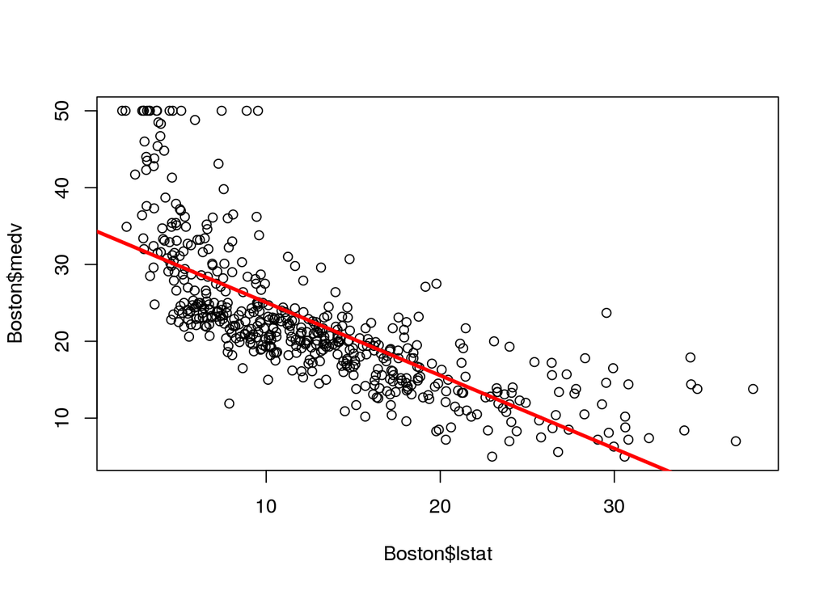

```r
plot(Boston$lstat,Boston$medv)
abline(lm.fit, lwd=3,col="red")
```

Four diagnostic plots are automatically produced by applying the `plot()` function directly to the output from `lm()`. It is often convenient to view all four plots together. We can achieve this by using the `par()` function, which tell `R` to split the display screen into separete panels so that multiple plots can be viewed simultaneously.

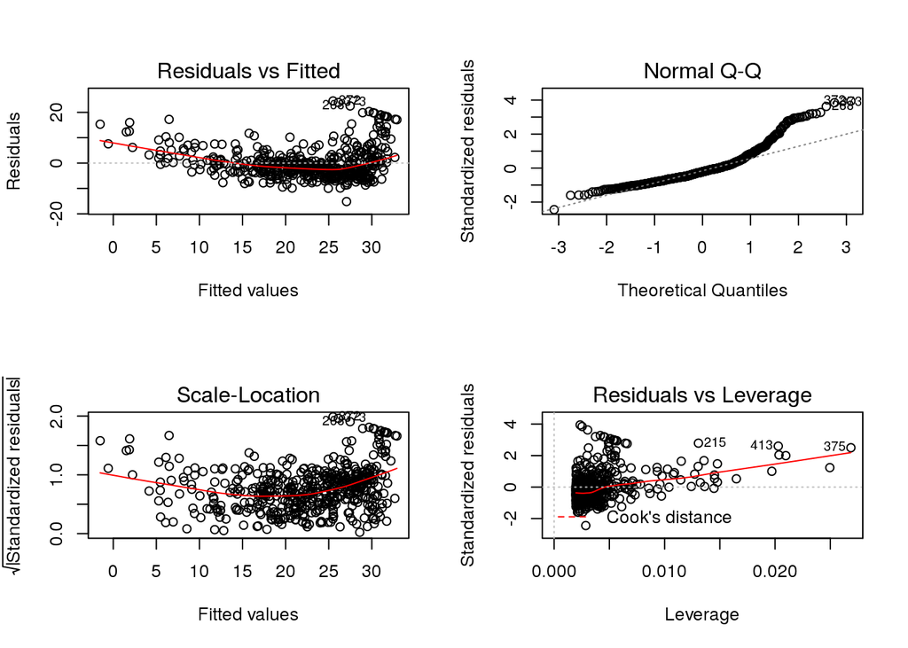

```r
par(mfrow=c(2,2))
plot(lm.fit)
```

Alternatively, we can compute the residuals from a linear regression fit using the `residuals()` function. The function `rstudent()` will return the studentized residuals, and we can use this function to plot the redisuals against the fitted values.

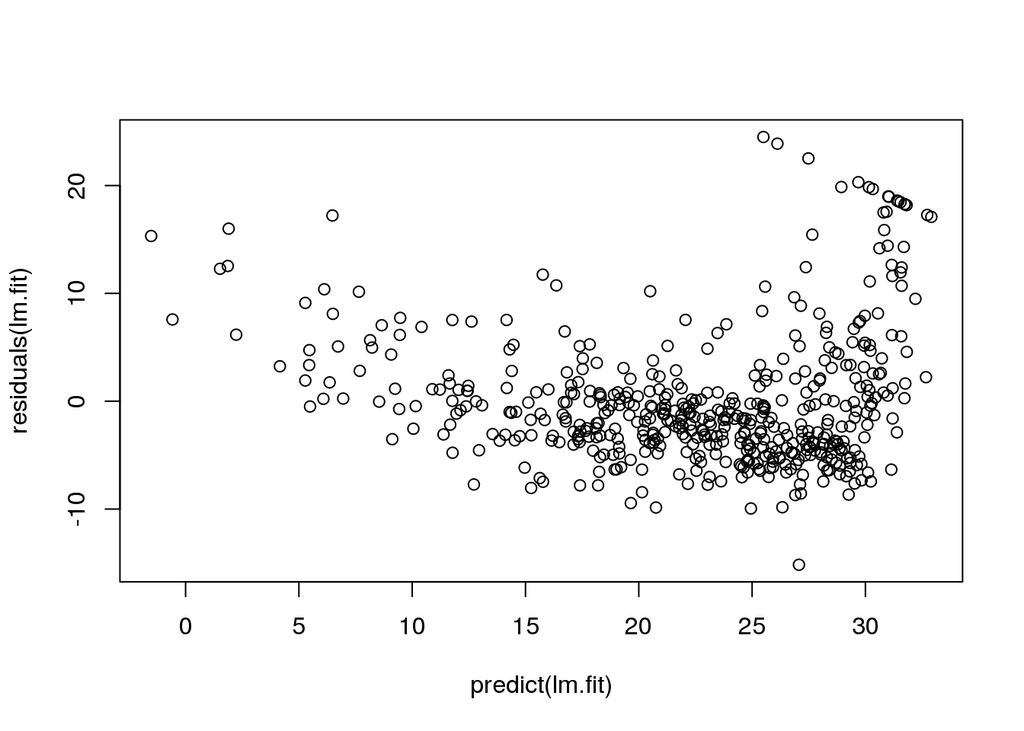

```r
plot(predict(lm.fit), residuals(lm.fit))
```

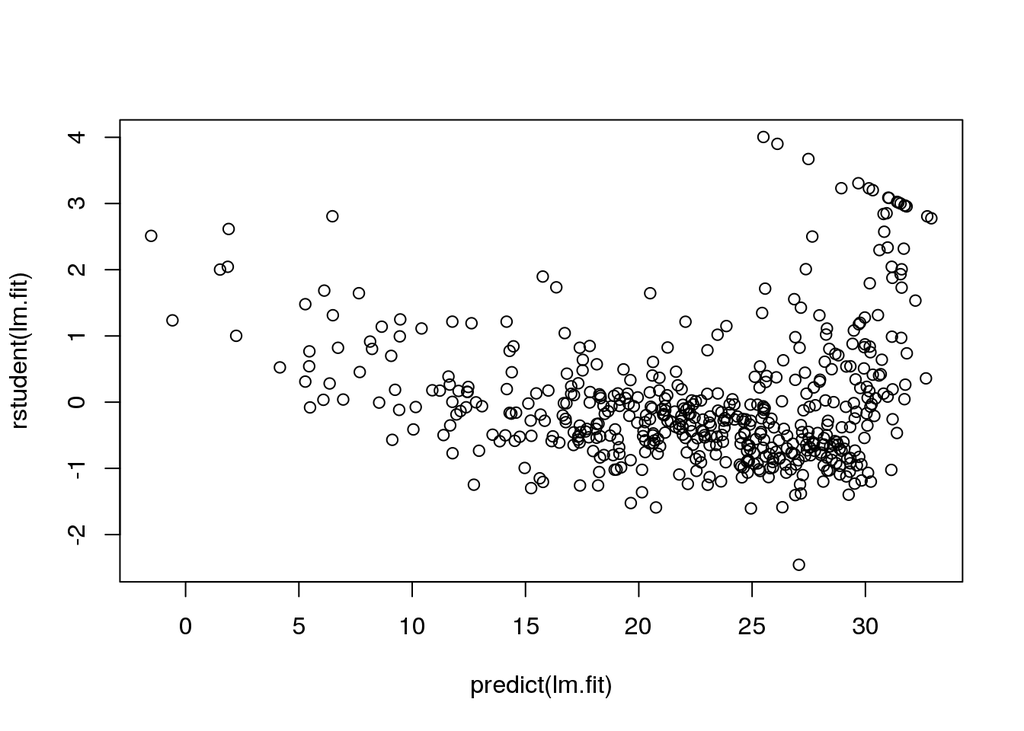

```r
plot(predict(lm.fit), rstudent(lm.fit))
```

On the basis of the residuals plots, there is some evidence of non-linearity. Leverage statistics can be computed for any number of predictors using the `hatvalues()` function.

The `which.max()` function identifies the index of the largest element of a vector. In this case, it tells us which obs has the larsgest leverage

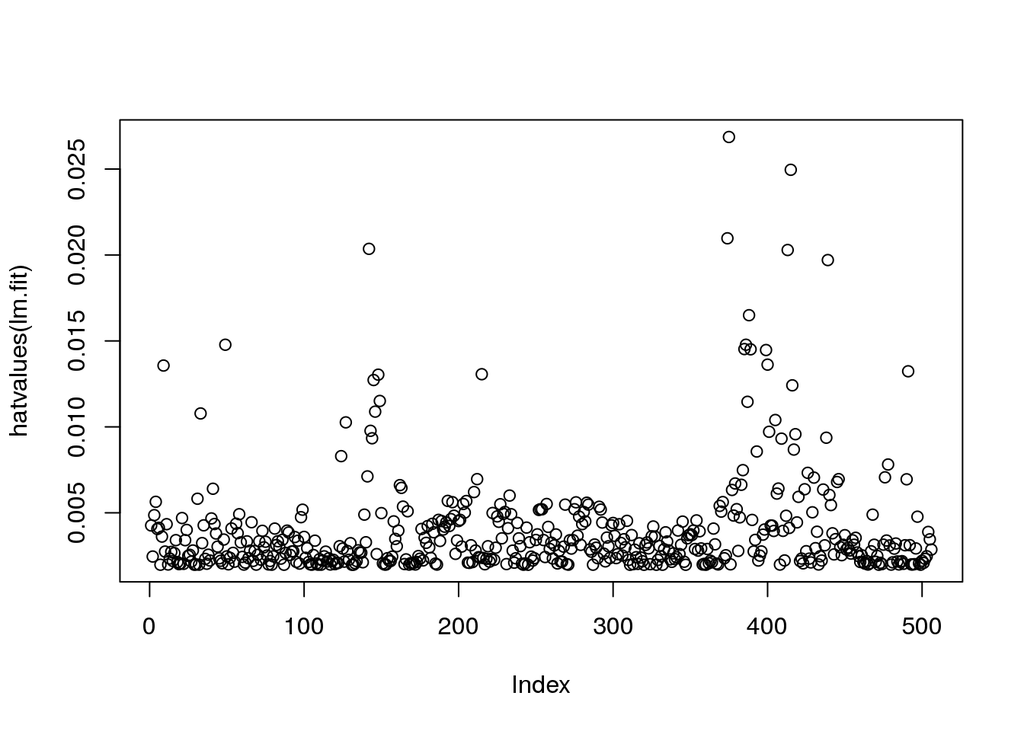

```r
plot(hatvalues(lm.fit))
```

```r
which.max(hatvalues(lm.fit))
```

```
## 375
## 375
```

### Multiple Linear Regression

In order to fit a multiple linear regression model using least squres, we again use the `lm()` function.

```r
lm.fit=lm(medv~lstat+age, data=Boston)
summary(lm.fit)
```

```
##
## Call:
## lm(formula = medv ~ lstat + age, data = Boston)
##
## Residuals:
##     Min      1Q  Median      3Q     Max
## -15.981  -3.978  -1.283   1.968  23.158
##
## Coefficients:
##             Estimate Std. Error t value Pr(>|t|)
## (Intercept) 33.22276    0.73085  45.458  < 2e-16 ***
## lstat       -1.03207    0.04819 -21.416  < 2e-16 ***
## age          0.03454    0.01223   2.826  0.00491 **
## ---
## Signif. codes:  0 '***' 0.001 '**' 0.01 '*' 0.05 '.' 0.1 ' ' 1
##
## Residual standard error: 6.173 on 503 degrees of freedom
## Multiple R-squared:  0.5513, Adjusted R-squared:  0.5495
## F-statistic:   309 on 2 and 503 DF,  p-value: < 2.2e-16
```

The `Boston` data set contains 13 variables, and so it would be cumbersome to have to tye all of these in order to perform a regression using all of the predictors. Instead, we can use the following short-hand:

```r
lm.fit=lm(medv~., data=Boston)
summary(lm.fit)
```

```
##
## Call:
## lm(formula = medv ~ ., data = Boston)
##
## Residuals:
##     Min      1Q  Median      3Q     Max
## -15.595  -2.730  -0.518   1.777  26.199
##
## Coefficients:
##               Estimate Std. Error t value Pr(>|t|)
## (Intercept)  3.646e+01  5.103e+00   7.144 3.28e-12 ***
## crim        -1.080e-01  3.286e-02  -3.287 0.001087 **
## zn           4.642e-02  1.373e-02   3.382 0.000778 ***
## indus        2.056e-02  6.150e-02   0.334 0.738288
## chas         2.687e+00  8.616e-01   3.118 0.001925 **
## nox         -1.777e+01  3.820e+00  -4.651 4.25e-06 ***
## rm           3.810e+00  4.179e-01   9.116  < 2e-16 ***
## age          6.922e-04  1.321e-02   0.052 0.958229
## dis         -1.476e+00  1.995e-01  -7.398 6.01e-13 ***
## rad          3.060e-01  6.635e-02   4.613 5.07e-06 ***
## tax         -1.233e-02  3.760e-03  -3.280 0.001112 **
## ptratio     -9.527e-01  1.308e-01  -7.283 1.31e-12 ***
## black        9.312e-03  2.686e-03   3.467 0.000573 ***
## lstat       -5.248e-01  5.072e-02 -10.347  < 2e-16 ***
## ---
## Signif. codes:  0 '***' 0.001 '**' 0.01 '*' 0.05 '.' 0.1 ' ' 1
##
## Residual standard error: 4.745 on 492 degrees of freedom
## Multiple R-squared:  0.7406, Adjusted R-squared:  0.7338
## F-statistic: 108.1 on 13 and 492 DF,  p-value: < 2.2e-16
```

We can access the individual components of a summary object by name.

```r
summary(lm.fit)$r.sq # give us the R-squared
```

```
## [1] 0.7406427
```

```r
summary(lm.fit)$sigma # give us the RSE
```

```
## [1] 4.745298
```

The `vif()` function, part of the `car` package, can be used to compute variance inflation factors. Most VIF’s are low to moderate for this data.

```r
library(car)
vif(lm.fit)
```

```
##     crim       zn    indus     chas      nox       rm      age      dis
## 1.792192 2.298758 3.991596 1.073995 4.393720 1.933744 3.100826 3.955945
##      rad      tax  ptratio    black    lstat
## 7.484496 9.008554 1.799084 1.348521 2.941491
```

What if we would like to perform a regression using all of the variable but one?

```r
lm.fit1=lm(medv~.-age,data=Boston)
summary(lm.fit1)
```

```
##
## Call:
## lm(formula = medv ~ . - age, data = Boston)
##
## Residuals:
##      Min       1Q   Median       3Q      Max
## -15.6054  -2.7313  -0.5188   1.7601  26.2243
##
## Coefficients:
##               Estimate Std. Error t value Pr(>|t|)
## (Intercept)  36.436927   5.080119   7.172 2.72e-12 ***
## crim         -0.108006   0.032832  -3.290 0.001075 **
## zn            0.046334   0.013613   3.404 0.000719 ***
## indus         0.020562   0.061433   0.335 0.737989
## chas          2.689026   0.859598   3.128 0.001863 **
## nox         -17.713540   3.679308  -4.814 1.97e-06 ***
## rm            3.814394   0.408480   9.338  < 2e-16 ***
## dis          -1.478612   0.190611  -7.757 5.03e-14 ***
## rad           0.305786   0.066089   4.627 4.75e-06 ***
## tax          -0.012329   0.003755  -3.283 0.001099 **
## ptratio      -0.952211   0.130294  -7.308 1.10e-12 ***
## black         0.009321   0.002678   3.481 0.000544 ***
## lstat        -0.523852   0.047625 -10.999  < 2e-16 ***
## ---
## Signif. codes:  0 '***' 0.001 '**' 0.01 '*' 0.05 '.' 0.1 ' ' 1
##
## Residual standard error: 4.74 on 493 degrees of freedom
## Multiple R-squared:  0.7406, Adjusted R-squared:  0.7343
## F-statistic: 117.3 on 12 and 493 DF,  p-value: < 2.2e-16
```

### Interaction Terms

It is easy to include interaction terms in a linear model using the `lm()` function. The syntax `lstat:black` tells `R` to include an interaction term between `lstat` and `black`. The syntax `lstat*age` simultaneously includes `lstat`, `age`, and the interaction term `lstat`x`age` as predictors; it is a shorthand for `lstat+age+lstat:age`.

```r
summary(lm(medv~lstat*age, data=Boston))
```

```
##
## Call:
## lm(formula = medv ~ lstat * age, data = Boston)
##
## Residuals:
##     Min      1Q  Median      3Q     Max
## -15.806  -4.045  -1.333   2.085  27.552
##
## Coefficients:
##               Estimate Std. Error t value Pr(>|t|)
## (Intercept) 36.0885359  1.4698355  24.553  < 2e-16 ***
## lstat       -1.3921168  0.1674555  -8.313 8.78e-16 ***
## age         -0.0007209  0.0198792  -0.036   0.9711
## lstat:age    0.0041560  0.0018518   2.244   0.0252 *
## ---
## Signif. codes:  0 '***' 0.001 '**' 0.01 '*' 0.05 '.' 0.1 ' ' 1
##
## Residual standard error: 6.149 on 502 degrees of freedom
## Multiple R-squared:  0.5557, Adjusted R-squared:  0.5531
## F-statistic: 209.3 on 3 and 502 DF,  p-value: < 2.2e-16
```

### Non-linear Transformations of the Predictors

The `lm()` function can also accomodate non-linear transformations of the predictors. For instance, given a predictor X, we can create a predictor X-squared using `I(X^2)`. The function `I()` is needed since the `^` has a special meaning in a formula; wrapping as we do allows the standard usage in `R`, which is to raise `X` to the power `2`. We now perform a regression of `medv` onto `lstat` and `lstat`-squared.

```r
lm.fit2=lm(medv~lstat+I(lstat^2),data=Boston)
summary(lm.fit2)
```

```
##
## Call:
## lm(formula = medv ~ lstat + I(lstat^2), data = Boston)
##
## Residuals:
##      Min       1Q   Median       3Q      Max
## -15.2834  -3.8313  -0.5295   2.3095  25.4148
##
## Coefficients:
##              Estimate Std. Error t value Pr(>|t|)
## (Intercept) 42.862007   0.872084   49.15   <2e-16 ***
## lstat       -2.332821   0.123803  -18.84   <2e-16 ***
## I(lstat^2)   0.043547   0.003745   11.63   <2e-16 ***
## ---
## Signif. codes:  0 '***' 0.001 '**' 0.01 '*' 0.05 '.' 0.1 ' ' 1
##
## Residual standard error: 5.524 on 503 degrees of freedom
## Multiple R-squared:  0.6407, Adjusted R-squared:  0.6393
## F-statistic: 448.5 on 2 and 503 DF,  p-value: < 2.2e-16
```

The near-zero p-value associated with the quadratic term suggests that it leads to an improved model. We use the `anova()` function to further quantify the extent to which the quadratitc fit is superior to the linear fit.

```r
lm.fit=lm(medv~lstat, data=Boston)
anova(lm.fit,lm.fit2)
```

```
## Analysis of Variance Table
##
## Model 1: medv ~ lstat
## Model 2: medv ~ lstat + I(lstat^2)
##   Res.Df   RSS Df Sum of Sq     F    Pr(>F)
## 1    504 19472
## 2    503 15347  1    4125.1 135.2 < 2.2e-16 ***
## ---
## Signif. codes:  0 '***' 0.001 '**' 0.01 '*' 0.05 '.' 0.1 ' ' 1
```

Here Model 1 represents the linear submodel containing only one predictor, `lstat`, while Model 2 corresponds to the larger quadratic model that has two predictors, `lstat` and `last`-squared. The `anova()` function performs a hypothesis test comparing the two models. The null hypothesis is that the two models fit the data equally well, and the alternative hypothesis is that the full model is superior. Here the F-statistic is 135 and the associated p-value is virtually zero. This provides very clear evidence that the model containing the predictors `lstat` and `last'-squared is far superior to the model that only contains the predictor`lstat`. This is not surprising, since earlier we saw evidence for non-linearity in the relationship between`medv`and`lstat`. If we type

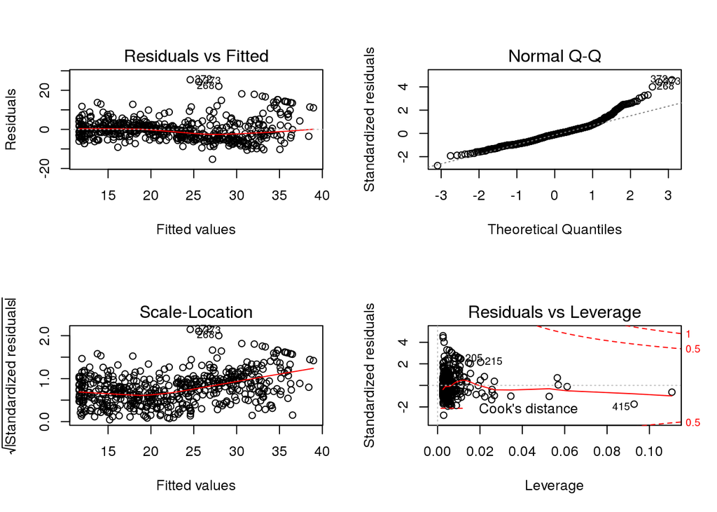

```r
par(mfrow=c(2,2))
plot(lm.fit2)
```

then we see that when the `lstat`-squared term is included in the model, there is little discernible pattern in the residuals.

In order to create a cubic fit, we can include a predictor of the form `I(X^3)`. However, this approach can start to get cumbersome for highr-order polynomials. A better approach involves using the `poly()` function to create the polynomial within `lm()`. For example the following command produces a fifth-order polynomial fit.

```r
lm.fit5=lm(medv~poly(lstat,5),data=Boston)
summary(lm.fit5)
```

```
##
## Call:
## lm(formula = medv ~ poly(lstat, 5), data = Boston)
##
## Residuals:
##      Min       1Q   Median       3Q      Max
## -13.5433  -3.1039  -0.7052   2.0844  27.1153
##
## Coefficients:
##                  Estimate Std. Error t value Pr(>|t|)
## (Intercept)       22.5328     0.2318  97.197  < 2e-16 ***
## poly(lstat, 5)1 -152.4595     5.2148 -29.236  < 2e-16 ***
## poly(lstat, 5)2   64.2272     5.2148  12.316  < 2e-16 ***
## poly(lstat, 5)3  -27.0511     5.2148  -5.187 3.10e-07 ***
## poly(lstat, 5)4   25.4517     5.2148   4.881 1.42e-06 ***
## poly(lstat, 5)5  -19.2524     5.2148  -3.692 0.000247 ***
## ---
## Signif. codes:  0 '***' 0.001 '**' 0.01 '*' 0.05 '.' 0.1 ' ' 1
##
## Residual standard error: 5.215 on 500 degrees of freedom
## Multiple R-squared:  0.6817, Adjusted R-squared:  0.6785
## F-statistic: 214.2 on 5 and 500 DF,  p-value: < 2.2e-16
```

This suggests that including additional polynomial terms, up to fifth order, leads to an improvement in the model fit. However, further investigation of the data reveals that no polynomials terms beyond fifth order have significant p-values in regression fit.

Of course, we are in no way restricted to using polynomial transformations of the predictors. Here we try a log transformation

```r
summary(lm(medv~log(rm),data=Boston))
```

```
##
## Call:
## lm(formula = medv ~ log(rm), data = Boston)
##
## Residuals:
##     Min      1Q  Median      3Q     Max
## -19.487  -2.875  -0.104   2.837  39.816
##
## Coefficients:
##             Estimate Std. Error t value Pr(>|t|)
## (Intercept)  -76.488      5.028  -15.21   <2e-16 ***
## log(rm)       54.055      2.739   19.73   <2e-16 ***
## ---
## Signif. codes:  0 '***' 0.001 '**' 0.01 '*' 0.05 '.' 0.1 ' ' 1
##
## Residual standard error: 6.915 on 504 degrees of freedom
## Multiple R-squared:  0.4358, Adjusted R-squared:  0.4347
## F-statistic: 389.3 on 1 and 504 DF,  p-value: < 2.2e-16
```

### Qualitative Predictors

We will now examine the `Carseats` data, which is part of the `ISLR` library. We will attempt to predict `Sales` in 400 locations based on a number of predictors.

```r
names(Carseats)
```

```
##  [1] "Sales"       "CompPrice"   "Income"      "Advertising" "Population"
##  [6] "Price"       "ShelveLoc"   "Age"         "Education"   "Urban"
## [11] "US"
```

The `Carseats` data includes qualitative predictors such as `Shelveloc`, an indicator of the quality of the shelving location, the space within a store in which the car seat is displayed, at each location. The predictor `Shelveloc` takes on three possible values, *Bad*, *Medium* and *Good*.

Given a qualitative variable such as `Shelveloc`, `R` generates dummy variables automatically. Below we fit a multiple regression model that includes some interaction termis.

```r
lm.fit=lm(Sales~.+Income:Advertising+Price:Age,data=Carseats)
summary(lm.fit)
```

```
##
## Call:
## lm(formula = Sales ~ . + Income:Advertising + Price:Age, data = Carseats)
##
## Residuals:
##     Min      1Q  Median      3Q     Max
## -2.9208 -0.7503  0.0177  0.6754  3.3413
##
## Coefficients:
##                      Estimate Std. Error t value Pr(>|t|)
## (Intercept)         6.5755654  1.0087470   6.519 2.22e-10 ***
## CompPrice           0.0929371  0.0041183  22.567  < 2e-16 ***
## Income              0.0108940  0.0026044   4.183 3.57e-05 ***
## Advertising         0.0702462  0.0226091   3.107 0.002030 **
## Population          0.0001592  0.0003679   0.433 0.665330
## Price              -0.1008064  0.0074399 -13.549  < 2e-16 ***
## ShelveLocGood       4.8486762  0.1528378  31.724  < 2e-16 ***
## ShelveLocMedium     1.9532620  0.1257682  15.531  < 2e-16 ***
## Age                -0.0579466  0.0159506  -3.633 0.000318 ***
## Education          -0.0208525  0.0196131  -1.063 0.288361
## UrbanYes            0.1401597  0.1124019   1.247 0.213171
## USYes              -0.1575571  0.1489234  -1.058 0.290729
## Income:Advertising  0.0007510  0.0002784   2.698 0.007290 **
## Price:Age           0.0001068  0.0001333   0.801 0.423812
## ---
## Signif. codes:  0 '***' 0.001 '**' 0.01 '*' 0.05 '.' 0.1 ' ' 1
##
## Residual standard error: 1.011 on 386 degrees of freedom
## Multiple R-squared:  0.8761, Adjusted R-squared:  0.8719
## F-statistic:   210 on 13 and 386 DF,  p-value: < 2.2e-16
```

The `contrast()` function returns the coding that `R` uses for the dummy variables.

```r
contrasts(Carseats$ShelveLoc)
```

```
##        Good Medium
## Bad       0      0
## Good      1      0
## Medium    0      1
```

`R` has created a `ShelveLocGood` dummy variable that takes on a value of 1 if the shelving location is good, and 0 otherwise. It has also created a `ShelveLocMedium` dummy variable that equals 1 if the shelving location is medium, and 0 otherwise. A bad shelving location corresponds to a zero for each of the two dummy variables. The fact that the coefficient for `ShelveLocGood` in the regression output is positive indicates that a good shelvig location is associated with high sales. And `ShelveLocMedium` has a smaller positive coefficient, indicating that a medium shelving location leads to higher sales than a bad shelving location but lower sales than a good shelving location.

### Writing Functions

As we have seen, `R` comes with useful functions, and still more functions are available by way of `R` libraries. However, we will often be interested in performing an operation for which no function is available. In this setting, we may want to write our own function. For instance, below we provide a simple function that reads in the `ISLR` and `MASS` libraries, called `LoadLibraries()`. The `{` symbol informs `R` that multiple commands are about to be input.

```r
LoadLibraries=function(){
  library(ISLR)
  library(MASS)
  print("The libraries have been loaded.")
}
LoadLibraries # tell us what is in the function
```

```
## function(){
##   library(ISLR)
##   library(MASS)
##   print("The libraries have been loaded.")
## }
```

```r
LoadLibraries() # we call the  function
```

```
## [1] "The libraries have been loaded."
```